# Study on stress-adaptation and visuospatial social memory: Power analysis and sample size determination

#### Gabriele Paone, Arran J Davis, Emma Cohen

##### Institute of Human Sciences, University of Oxford

##### arran.davis@anthro.ox.ac.uk | davis.arran@gmail.com

##### 30 September 2022

## Introduction

Previous research has suggested that exposure to environmental stress during development may enhance memory for social information (e.g., memory of previous encounters or individual recognition). We hypothesize that children from higher-stress areas of Naples, Italy (Scampia and a Roma camp) will score higher in working and short-term memory tasks that use social stimuli than will children from a lower-stress environment in the same metropolitan area (Pozzuoli).

## Data simulation

The outcome variables are performance in two tasks measuring: (1) visuospatial social short-term memory and (2) visuospatial social working memory.

The study will include participants from three different environments within Naples, Italy: one group from Scampia (higher-stress), a second one from a Roma camp (higher-stress), and a third one from Pozzuoli (lower-stress).

Here, we assuming that the effects on the outcome variables of each higher-stress environment will be the same (relative to the lower-stress environment).

To estimate visuospatial social short-term memory scores for this study, we used as a reference the means and standard deviations for verbal short-term memory (*M* = 4.9, *SD* = 1) found with the PML-2 battery test (D’Amico & Lipari, 2020), as our visuospatial social short-term memory tests followed the PML-2 battery test methods, except using social stimuli (faces of strangers). For each population, we assumed that visuospatial social working memory scores would be one point less than they were for visuospatial social short-term memory (this was based on piloting).

We assumed an effect of 0.5 of higher-stress environments on both outcome variables (i.e., that the Roma camp and Scampia population means would be 0.5 greater than the Pozzuoli population mean). We assumed standard deviations of 1 for all outcome in all populations, except for Pozzuoli visuospatial social working memory (hypothesised to have the lowest mean scores), which we assumed to have a standard deviations of 0.75 (owing to the minimum score floor of 2).

Assuming the above, and an overall mean score of 4.9 (D’Amico & Lipari, 2020) on the visuospatial social short-term memory test, we created the following distributions for each population and outcome variable:

- Roma camp and Scampia scores on visuospatial social short-term memory: *M* = 5.15 (*SD* = 1)
- Pozzuoli scores on visuospatial social short-term memory: *M* = 4.65 (*SD* = 1)
- Roma camp and Scampia scores on visuospatial social working memory: *M* = 4.15 (*SD* = 1)
- Pozzuoli scores on visuospatial social short-term memory: *M* = 3.65 (*SD* = 0.75)

This led to the following data simulation.

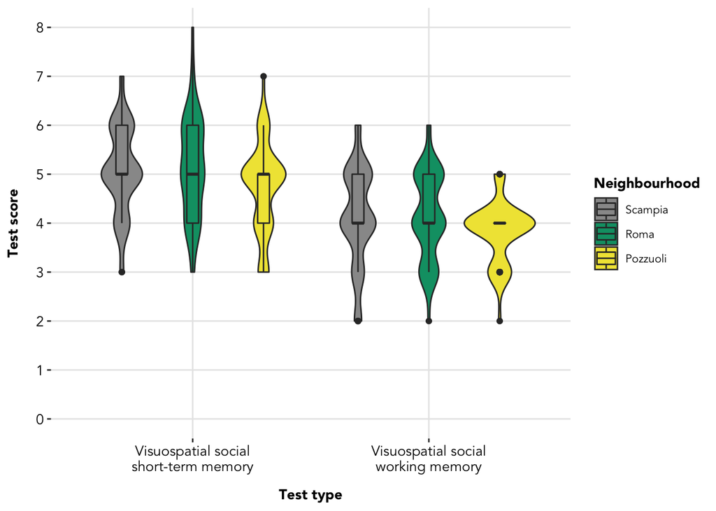

## Power analyses

The following model was run on each of the 2,500 simulated sample datasets; treatment contrasts where used for the `environment` variable, with the lower-stress population (Pozzuoli) being the baseline or reference category.

```
lm(test_score ~ environment, data = data)
```

The power analyses reported below were calculated as the frequency of the 2,500 *p*-values that were less than 0.05 for the *b*-coefficient that compared the Roma camp to Pozzuoli (the effects of both high-stress environments were assumed to be the same, so only one comparison was necessary).

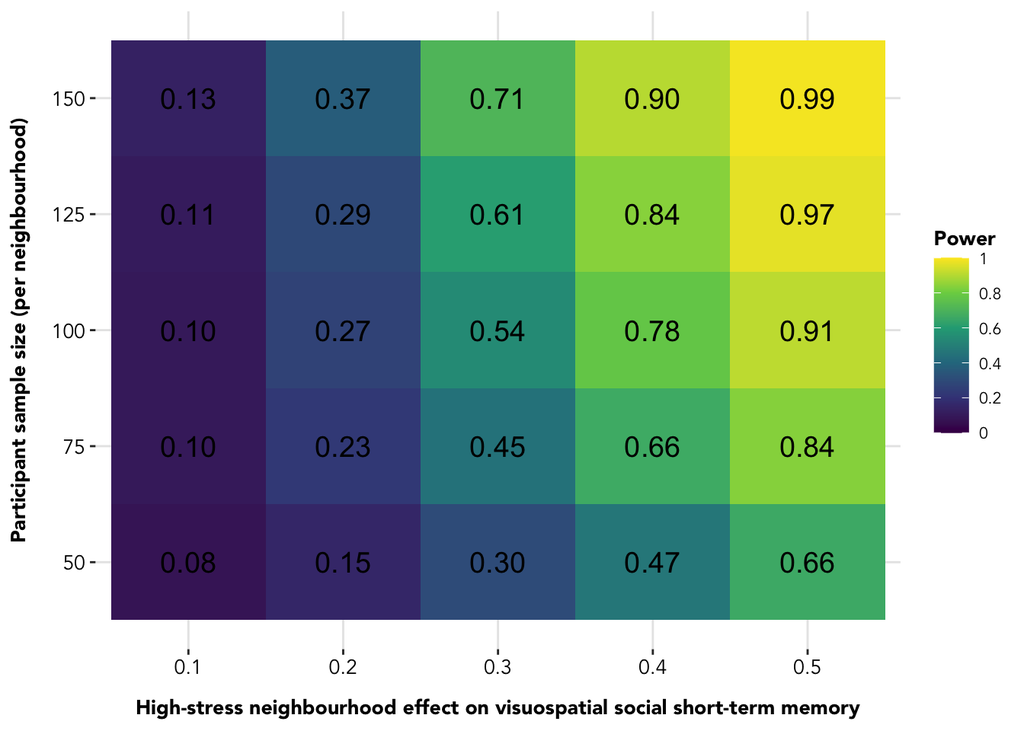

## Citations

DeBruine L (2021). *faux: Simulation for Factorial Designs*. doi: 10.5281/zenodo.2669586, R package version 1.1.0, https://debruine.github.io/faux/.

D’Amico, A., & Lipari, C. (2020). *PML-2. Prove per la misurazione della memoria di lavoro*. Galton.